# Uncertainty and Surprise Jointly Predict Musical Pleasure and Amygdala, Hippocampus, and Auditory Cortex Activity - ScienceDirect

[figure not shown]

## Current Biology

[Volume 29, Issue 23](https://www.sciencedirect.com/journal/current-biology/vol/29/issue/23), 2 December 2019, Pages 4084-4092.e4

# Report Uncertainty and Surprise Jointly Predict Musical Pleasure and Amygdala, Hippocampus, and Auditory Cortex Activity

[Vincent K.M.Cheung<sup>1</sup>](https://www.sciencedirect.com/science/article/pii/S0960982219312588#!)[Peter M.C.Harrison<sup>2</sup>](https://www.sciencedirect.com/science/article/pii/S0960982219312588#!)[LarsMeyer<sup>3</sup>](https://www.sciencedirect.com/science/article/pii/S0960982219312588#!)[Marcus T.Pearce<sup>2</sup><sup>4</sup>](https://www.sciencedirect.com/science/article/pii/S0960982219312588#!)[John-DylanHaynes<sup>5</sup>](https://www.sciencedirect.com/author/9741021000/john-dylan-haynes)[StefanKoelsch<sup>1</sup><sup>6</sup><sup>7</sup>](https://www.sciencedirect.com/science/article/pii/S0960982219312588#!)

https://doi.org/10.1016/j.cub.2019.09.067[Get rights and content](https://s100.copyright.com/AppDispatchServlet?publisherName=ELS&contentID=S0960982219312588&orderBeanReset=true)

Under an Elsevier [user license](https://www.elsevier.com/open-access/userlicense/1.0/)

Open archive

Referred to by

David Huron

[Musical Aesthetics: Uncertainty and Surprise Enhance Our Enjoyment of Music](https://www.sciencedirect.com/science/article/pii/S0960982219313612)

Current Biology, Volume 29, Issue 23, 2 December 2019, Pages R1238-R1240

[Download PDF](https://www.sciencedirect.com/science/article/pii/S0960982219313612/pdfft?md5=94e44391f0d85165c609614ba66f0ec4&pid=1-s2.0-S0960982219313612-main.pdf)

## Highlights

**•**

Musical pleasure depends on prospective and retrospective states of expectation

**•**

A machine-learning model quantified the uncertainty and surprise of pop song chords

**•**

Chords with low uncertainty and high surprise, and vice versa, evoked high pleasure

**•**

Joint effects of uncertainty and surprise found in the amygdala and auditory cortex

## Summary

Listening to music often evokes intense emotions [1, 2]. Recent research suggests that musical pleasure comes from positive reward prediction errors, which arise when what is heard proves to be better than expected [3]. Central to this view is the engagement of the nucleus accumbens—a brain region that processes reward expectations—to pleasurable music and surprising musical events [4, 5, 6, 7, 8]. However, expectancy violations along multiple musical dimensions (e.g., harmony and melody) have failed to implicate the [nucleus accumbens](https://www.sciencedirect.com/topics/agricultural-and-biological-sciences/nucleus-accumbens) [9, 10, 11], and it is unknown how music reward value is assigned [12]. Whether changes in musical expectancy elicit pleasure has thus remained elusive [11]. Here, we demonstrate that pleasure varies nonlinearly as a function of the listener’s uncertainty when anticipating a musical event, and the surprise it evokes when it deviates from expectations. Taking Western tonal harmony as a model of musical syntax, we used a machine-learning model [13] to mathematically quantify the uncertainty and surprise of 80,000 chords in US Billboard pop songs. Behaviorally, we found that chords elicited high pleasure ratings when they deviated substantially from what the listener had expected (low uncertainty, high surprise) or, conversely, when they conformed to expectations in an uninformative context (high uncertainty, low surprise). Neurally, we found using fMRI that activity in the amygdala, hippocampus, and [auditory cortex](https://www.sciencedirect.com/topics/agricultural-and-biological-sciences/auditory-cortex) reflected this interaction, while the nucleus accumbens only reflected uncertainty. These findings challenge current neurocognitive models of music-evoked pleasure and highlight the synergistic interplay between prospective and retrospective states of expectation in the musical experience.

### Video Abstract

#### Media player

[video not shown]

0 seconds

[Download : Download video (56MB)](https://ars.els-cdn.com/content/image/1-s2.0-S0960982219312588-mmc4.mp4)

## Keywords

aesthetics

amygdala

emotions

fMRI

information theory

nucleus accumbens

prediction

predictive coding

reward

syntax

## Results

Humans use structured sound sequences known as music to express and evoke emotions [1]. Manipulating the listener’s expectations is a key mechanism through which music elicits pleasure [1, 2, 14, 15, 16]. A fundamental concept and characteristic feature of Western music is tonal harmony, which describes the syntactic regularities of how simultaneous pitches are combined into chords, and how chords are related to other chords in a progression [17]. In this study, we directly addressed whether musical pleasure depended on the expectancy of individual chords in a progression (Experiment 1), and how that was reflected in human brain activity (Experiment 2).

### Quantifying Uncertainty and Surprise with Information Theory

As music unfolds in time, the listener continuously forms expectations on upcoming temporal and acoustic features [3, 13, 18]. This implies the presence of two temporally dissociable states through which the expectancy of a chord can evoke pleasure: the uncertainty when anticipating what the next chord could be before it occurs, and the surprise elicited when the actual chord deviates from expectations [16, 19]. In contrast, the existing literature has almost exclusively focused on surprising musical events [19, 20] and found inconclusive effects on musical pleasure [6, 11].

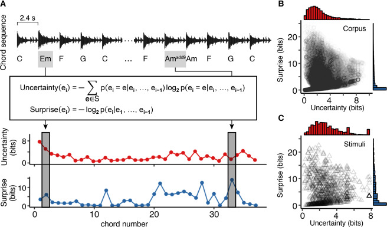

Figure 1. Quantifying Uncertainty and Surprise of a Chord

(A) An unsupervised statistical-learning model was trained on a corpus of 745 US Billboard “Hot 100” pop songs to derive the uncertainty (red) and surprise (blue) of chords (here, “Knowing Me, Knowing You” by ABBA; refer to Audio S1). Uncertainty is the lack of a clear expectation when anticipating an event *before* it is heard, while surprise occurs when what is *actually* heard deviates from expectations. Uncertainty of chord $ei$is quantified by its entropy, or expected negative log-probability, taken across the set of all chords $S$ in the corpus and conditional on the previous context of chords ${e1,…,ei−1}$ in the progression. Surprise of chord $ei$is quantified by its information content, and is the negative log-probability of the actual chord conditional on the context. Gray bars indicate points of high uncertainty but low surprise, and low uncertainty but high surprise. Subjects (n = 79) were asked to either rate the pleasantness of each chord (2.4 s) from 30 pop song chord progressions behaviorally or listen attentively and focus on how they fitted together in the context while undergoing fMRI scanning.

(B and C) Scatterplot and marginal densities of the uncertainty and surprise for all chords in the McGill Billboard corpus [21] (circles, n = 80,943) and in our chord stimuli (triangles, n = 1,039; Table S1).

### Experiment 1: Joint Effects of Uncertainty and Surprise on Musical Pleasure

In Experiment 1, healthy adults (n = 39) listened to 1,039 chords in 30 chord progressions (Table S1) selected from the 745 pop songs and rated the pleasantness of each chord using a mechanical slider. We only kept the chord progressions from the original songs (and removed the melody and rhythm) to ensure that our isochronous chord stimuli were not confounded by effects of other musical dimensions and familiarity (songs were confirmed to be unidentifiable by our subjects). We used a linear mixed model to analyze the extent to which uncertainty and surprise, and their interaction, predicted pleasantness of chords taken from the commercially successful pop songs. To account for temporal [autocorrelations](https://www.sciencedirect.com/topics/agricultural-and-biological-sciences/autocorrelation) in the slider ratings, we used a first-order autoregressive covariance structure to model the relationship between successive chords in each stimulus. To disambiguate probabilistic processing of expectations from [sensory processing](https://www.sciencedirect.com/topics/neuroscience/sensory-processing), we controlled for low-level acoustic features (i.e., sensory dissonance, spectral centroid, and spectral complexity) in the model (see Table S3 for correlations with chord uncertainty and surprise).

We found that the pleasure rating of a chord was significantly predicted by main effects of uncertainty and surprise, as well as their interaction (Figure 2; Table 1; see Table S2 for correlation of random effects). In other words, pleasantness depended on joint effects of the precision of the listener’s predictions, and the probability of the chord given the tonal harmonic context. Since the generation of an expectation precedes its deviation, we interpret this interaction as the modulatory effect of uncertainty on the effect of surprise on musical pleasure. When the uncertainty of the harmonic context was low (e.g., toward the end of a musical section), chords with higher surprise (i.e., those that were less probable) were rated as more pleasant than those with lower surprise. Conversely, when uncertainty was high (e.g., in chord progressions atypical of the listener’s musical experience), subjects rated chords that were less surprising as more pleasant (Figure 2B).

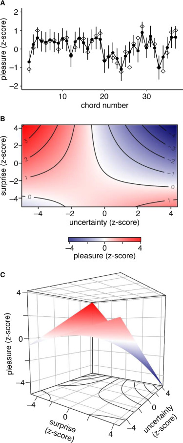

Figure 2. Uncertainty and Surprise Jointly Shape the Pleasure Rating of a Chord

(A) Standardized pleasure ratings to a chord progression taken from “Knowing Me, Knowing You” by ABBA (Audio S1). Diamonds indicate mean pleasantness ratings for each chord. Filled circles indicate fitted values from a linear mixed model with chord uncertainty, surprise, and their interaction as predictors. Error bars indicate 95% confidence intervals (95% CI). Low-level acoustic parameters were also included as covariates to control for sensory confounds.

(B) Contour plot demonstrating how pleasantness ratings jointly depend on uncertainty and surprise. When the tonal harmonic context does not allow for a prediction with high precision (i.e., when uncertainty is high), the pleasantness of a surprising chord is low. However, when the uncertainty is low, surprising chords are highly pleasurable.

(C) Data from (B) replotted in 3D. Although reminiscent of the characteristic inverted-U response from empirical aesthetics, the regression surface is in fact a saddle for which pleasantness varies nonlinearly across different levels of uncertainty and surprise.

Table 1. Parameter Estimates of the Linear Mixed Model in Experiment 1

| Fixed-Effect Predictor | Standardized β | 95% CI | Deviance | p |
| --- | --- | --- | --- | --- |
| Intercept | 0.0219 | [−0.0740, 0.118] | 0.200 | 0.655 |
| Uncertainty | −0.143 | [−0.186, −0.0989] | 40.2 | 2.33 × 10<sup>−10</sup><sup>∗∗∗</sup> |
| Surprise | −0.327 | [−0.418, −0.236] | 29.2 | 6.57 × 10<sup>−8</sup><sup>∗∗∗</sup> |
| Uncertainty × surprise | −0.124 | [−0.183, −0.0644] | 13.4 | 0.000246<sup>∗∗∗</sup> |
| Sensory dissonance | −0.251 | [−0.345, −0.158] | 19.3 | 1.41 × 10<sup>−5</sup><sup>∗∗∗</sup> |
| Spectral centroid | 0.0719 | [0.0244, 0.119] | 8.77 | 0.00306<sup>∗∗</sup> |
| Spectral complexity | 0.224 | [0.147, 0.300] | 23.0 | 1.65 × 10<sup>−6</sup><sup>∗∗∗</sup> |
| Overall pleasantness of sequence | 0.171 | [0.032, 0.309] | 5.28 | 0.0215<sup>∗</sup> |
| Overall arousal of sequence | −0.0321 | [−0.160, 0.0956] | 0.242 | 0.623 |

Subjects (n = 39) continuously rated the pleasantness of 1,039 chords in 30 chord sequences using a mechanical slider. The pleasantness of a chord depended on not only the amount of surprise evoked, but also the uncertainty in anticipating the chord before it was actually heard. Low-level acoustic effects were also introduced as covariates (see Table S3 for correlations with chord uncertainty and surprise) to disambiguate probabilistic processing from low-level [sensory processing](https://www.sciencedirect.com/topics/neuroscience/sensory-processing). Deviance here denotes twice the difference in log-likelihood between the full model and a restricted model with the effect omitted. Significance of individual fixed effects was determined using the likelihood-ratio test after a full-null model comparison [28, 29]. Marginal and conditional R<sup>2</sup> values for the model were estimated according to [30]. See Table S2 for correlation of random effects. Marginal R<sup>2</sup> = 0.476; conditional R<sup>2</sup> = 0.654; <sup>∗</sup>p < 0.05, <sup>∗∗</sup>p < 0.01, <sup>∗∗∗</sup>p < 0.001.

In fact, the regression surface (Figure 2C) resembled a saddle, where the multiplicative effect of uncertainty and surprise along the two diagonals predicted pleasantness in a parabolic (U/inverted-U) manner. This is reminiscent of Berlyne’s [31] influential model in empirical aesthetics, which postulated an inverted-U relationship between pleasure and variables such as exposure and complexity. Critically, however, our findings paint a more complicated and multifaceted picture of musical pleasure. Our findings imply that isolated effects of individual variables alone cannot fully explain the musical experience, as it is likely to be a nonlinear function of multiple interacting factors.

Furthermore, consistent with prior work [32, 33, 34, 35, 36], the low-level acoustic features also showed significant effects on pleasure (but were controlled for in the model). The magnitude of standardized beta estimates in our model (Table 1) indicated that when the uncertainty of the chord was at its mean, the effect of surprise was 30% larger than sensory dissonance, and this marginal effect became twice as large when chord uncertainty was increased to 1.5 SD above the mean.

### Experiment 2: Neural Basis of Uncertainty and Surprise in Music-Evoked Pleasure

To directly assess the underlying brain regions whose activity correlated with uncertainty and surprise, another group of subjects (n = 40) listened to the same isochronous chord stimuli and was instructed to pay attention to how the chords fitted together in the progression while undergoing fMRI scanning in Experiment 2. As before, we confirmed that our stimuli were unfamiliar to the subjects. Despite the sluggishness of the blood-oxygen-level-dependent (BOLD) response, the long duration of each chord (2.4 s) meant that metabolic changes could still be measured on a chord-to-chord level. We also used multiband echo-planar imaging (EPI) [37, 38] to allow for a sub-second temporal resolution while maintaining good spatial coverage. We focused our analysis on brain regions previously shown to be implicated in music-evoked emotions across multiple studies [1]: the bilateral amygdala and adjacent anterior hippocampus, bilateral [auditory cortex](https://www.sciencedirect.com/topics/agricultural-and-biological-sciences/auditory-cortex), right [nucleus accumbens](https://www.sciencedirect.com/topics/agricultural-and-biological-sciences/nucleus-accumbens), left [caudate nucleus](https://www.sciencedirect.com/topics/agricultural-and-biological-sciences/caudate-nucleus), and the pre-supplementary motor area. Given that musical pleasure depends on joint effects of uncertainty and surprise, we hypothesized that the underlying brain regions would also show the same interaction.

Consistent with our behavioral findings, we found in Experiment 2 (Figure 3; see Table S4 for parameter estimates) that the interaction between uncertainty and surprise significantly modulated the BOLD response in the bilateral amygdala and hippocampus (left: β = −0.116, corrected 95% CI = [−0.201, −0.0445], sign test: s = 11, corrected p = 0.0450; right: β = −0.140, corrected 95% CI = [−0.238, −0.0410], one-sample t test: t(39) = −4.02, corrected p = 0.00181; see also Figure S1). This is in line with prior studies implicating the amygdala in surprises in tonal harmony and changes in musical tension [26, 27], as well as the hippocampus in encoding the uncertainty of sequences [39, 40], and forming memory associations during music listening [5].

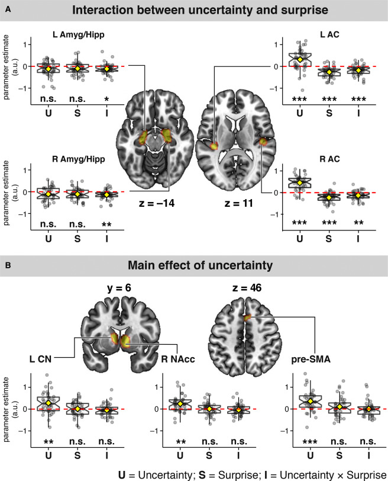

Figure 3. Neural Basis of Uncertainty and Surprise in Music-Evoked Pleasure

(A) Model-based fMRI revealed that BOLD activity in the bilateral amygdala and neighboring anterior hippocampus (Amyg/Hipp), as well as the bilateral auditory cortex (AC), is significantly modulated by the interaction of chord uncertainty and surprise.

(B) The right nucleus accumbens (NAcc), left caudate (CN), and pre-supplementary area (pre-SMA) instead only showed significant positive modulations to chord uncertainty. See also Figures S1–S3 and Table S4. Boxplots show parameter estimates for the effect of uncertainty, surprise, and their interaction in each region of interest (n = 40; filled circles, data points; solid line, median; diamond, mean; notches, 95% CI of the median; hinges, IQR; whiskers, 1.5<sup>∗</sup>IQR; statistical inferences were made using one-sample t tests (two-tailed) or sign tests (for non-normal data) and Bonferroni-corrected for multiple comparisons (n.s., p ≥ 0.05, <sup>∗</sup>p < 0.05, <sup>∗∗</sup>p < 0.01, <sup>∗∗∗</sup>p < 0.001).

Remarkably, neither a significant interaction between uncertainty and surprise nor a main effect of surprise was detected in the nucleus accumbens or caudate (all corrected p > 0.993). We instead detected a positive main effect of uncertainty in the right nucleus accumbens (β = 0.242, corrected 95% CI = [0.0720, 0.412], t(39) = 4.04, corrected p = 0.00170) and left caudate (β = 0.281, corrected 95% CI = [0.0661, 0.496], t(39) = 3.71, corrected p = 0.00447). This means striatal activity was increased when the tonal harmonic context was less informative in revealing what the ensuing chord could be and decreased when more informative. In a post hoc analysis, we found comparable results in the contralateral nucleus accumbens and caudate with no evidence of laterality (Figure S3). Our data therefore suggest that striatal activity encodes the uncertainty of an expectation, irrespective of the magnitude of surprise. Finally, the pre-supplementary motor area likewise only showed a significant positive modulation to uncertainty (β = 0.358, corrected 95% CI = [0.145, 0.570], t(39) = 4.78, corrected p = 0.000176).

## Discussion

Our results contribute direct evidence in support of an expectancy mechanism in evoking musical pleasure [2, 14, 15, 16, 18, 44]. We showed that surprise, a retrospective response, alone cannot fully explain the link between expectations in music and pleasure. Our data demonstrate that uncertainty, a prospective state of expectation, is another crucial dimension needed to describe this relationship. Pleasantness ratings to isochronous chord progressions taken from commercially successful Western pop music indicated high pleasure in two situations: when a chord with high surprise had been predicted with low uncertainty, or conversely, when a chord with low surprise had been predicted with high uncertainty. This interaction effect was reflected by metabolic changes in the amygdala, anterior hippocampus, and [auditory cortex](https://www.sciencedirect.com/topics/agricultural-and-biological-sciences/auditory-cortex), but not the [nucleus accumbens](https://www.sciencedirect.com/topics/agricultural-and-biological-sciences/nucleus-accumbens). Uncertainty and surprise are in fact key components of an influential predictive-coding model of neuronal message-passing across the cortical hierarchy [16, 20, 45]. In this model, music perception is construed as an active process where the brain continuously updates its generative model of the environment to minimize variational free-energy [16, 20]. Music may therefore elicit pleasure by encouraging the listener to continuously generate and resolve expectations as the piece unfolds in time [16, 20]. The importance of the temporal dimension in evoking pleasure sets music apart from the static visual objects that are traditionally studied in empirical aesthetics [46, 47].

Unlike prior studies [4, 7, 8, 48], which appealed to the established role of the nucleus accumbens in reward expectation [49, 50] as evidence supporting an expectancy mechanism of musical pleasure, we directly addressed how predictability in our stimuli modulated pleasantness. These studies also left unexplained which musical dimensions constituted an expected musical reward, and how reward value is assigned to musical events [12]. In contrast, our results indicate that musical pleasure comes from manipulating both the uncertainty of the listener’s expectations before hearing an event and the surprise that follows when such expectations are not met. Here, these events are chords represented on the symbolic level and objectively quantified using information theory. These chord expectations are likely generated, at least partly, in the inferior frontal gyrus, a region shown to process expectation deviations in musical structure [9, 18, 51], and passed top-down to the auditory cortex [16, 20, 44]. Since the uncertainty and surprise of a chord were derived independently from its acoustic characteristics and solely on its conditional probability of occurrence, the same chord will have a different level of uncertainty and surprise depending on the combination of chords prior in the progression. Combined with the control of low-level acoustic regressors, we can rule out that our results were driven by sensory-acoustic features.

Activity in the nucleus accumbens and caudate did not show significant modulation to the effect of chord surprise and its interaction with uncertainty. Given the central role of the nucleus accumbens in reward prediction, this might be seen as at odds with our behavioral finding that pleasantness is predicted by the joint effect of uncertainty and surprise. Instead, we found that uncertainty positively modulated striatal activity. Our results suggest that the striatum performs a facilitatory, although important, role in generating musical pleasure —that of modulating [incentive salience](https://www.sciencedirect.com/topics/neuroscience/incentive-salience), or the motivation or “wanting” of subsequent information that resolves uncertainty [44, 49]. In addition to reward expectation, the nucleus accumbens is argued to play a significant role in integrating cognitive and affective information to direct attention and modify actions toward motivationally relevant stimuli through dopaminergic pathways [50]. In line with this and consistent with our findings, dopamine is assumed to encode the precision (the inverse of uncertainty) of prediction errors in the free-energy principle [16, 20]. Indeed, causal studies on musical pleasure [48, 52] do not claim that striatal dopaminergic neurons induce pleasurable emotions per se, but highlight their necessity in regulating affective responses to music. Taken together, we suggest that a role of the nucleus accumbens in musical pleasure is to modulate attention deployment, depending on uncertainty, in the amygdala, hippocampus, and auditory cortex. In line with this, the nucleus accumbens has shown increased [functional connectivity](https://www.sciencedirect.com/topics/biochemistry-genetics-and-molecular-biology/functional-connectivity) with the amygdala, hippocampus, auditory cortex, and the inferior [frontal cortex](https://www.sciencedirect.com/topics/agricultural-and-biological-sciences/frontal-lobe) for music that was more pleasant [4, 6].

Our study has certain limitations. First, our [auditory stimuli](https://www.sciencedirect.com/topics/biochemistry-genetics-and-molecular-biology/auditory-stimulation) consisted of computer-generated isochronous chord progressions taken from original pop songs. Although this allowed us to isolate effects of harmonic expectancy by controlling for confounds such as rhythm, melody, familiarity, dynamics, and instrumentation, the expectancy of these other dimensions and the dimensions themselves are also likely to influence pleasure [2, 8, 15, 53, 54]. Second, the parametric values of uncertainty and surprise derived from our computational model are constrained by the corpus from which the statistical regularities are computed. In other words, a highly surprising chord predicted with low uncertainty here is only relative to other chords present in the McGill Billboard corpus of commercially successful pop songs [21]. Third, listeners’ experiences shape their internal model of the statistical regularities of chords in a progression [13]. This means that factors such as culture, genre, and style affect how surprising a chord is, and with how much precision it can be expected [13]. Whether our results extend to other musical styles (see, e.g., [55] for a discussion on atonal music), and the extent to which enculturation, expertise, and individual differences shape our preferences and emotional responses to music thus remain open questions.

In summary, we show with the help of an unsupervised statistical-learning model that musical pleasure depends on the dynamic interplay between prospective and retrospective states of expectation. We demonstrate that this joint effect is reflected by metabolic changes in the amygdala, hippocampus, and auditory cortex, and is likely mediated through dopaminergic incentive salience signals in the nucleus accumbens—which instead showed a positive modulation to uncertainty. Our fundamental ability to predict [16, 20] is therefore an important mechanism through which abstract sound sequences acquire affective meaning and transform into a universal cultural phenomenon that we call “music” [15].

## STAR★Methods

### Key Resources Table

| REAGENT or RESOURCE | SOURCE | IDENTIFIER |
| --- | --- | --- |
| **Deposited Data** |  |  |
| Brain-masks of regions involved in music-evoked emotions | [1] | https://doi.org/10.1038/nrn3666 |
| McGill Billboard Corpus | [21] | https://ddmal.music.mcgill.ca/research/The_McGill_Billboard_Project_(Chord_Analysis_Dataset)/ |
| **Software and Algorithms** |  |  |
| Statistical Parametric Mapping 12 (version 7219) | Wellcome Centre for Human Neuroimaging | https://www.fil.ion.ucl.ac.uk/spm/software/spm12/ |
| Information Dynamics Of Music (IDyOM) model | [56] | https://code.soundsoftware.ac.uk/projects/idyom-project |
| MATLAB 2017b | MathWorks | https://www.mathworks.com |
| R 3.5.1 | RStudio | https://rstudio.com/ |
| glmmTMB (fix_confint_ar1 branch) | [57] | https://github.com/glmmTMB/glmmTMB |
| MarsBar 0.44 | [58] | http://marsbar.sourceforge.net/ |

### Lead Contact and Materials Availability

Further information and requests for resources and reagents should be directed to and will be fulfilled by the Lead Contact, Stefan Koelsch (stefan.koelsch@uib.no). This study did not generate new unique reagents.

### Experimental Model and Subject Details

A total of 83 healthy human adults took part in the study. Data from one male subject in Experiment 1 was excluded due to non-compliance with the experimental procedure. Functional MRI data from two subjects (1 female, 1 male) in Experiment 2 were excluded due to data-handling errors, and one further female subject was excluded as her overall music reward score (see below) was over 3 standard deviations below the population mean. Subjects took part in either the behavioral or fMRI experiment, but not both to ensure that the stimuli were novel to the subjects.

For Experiment 1, data were analyzed from 39 subjects with diverse levels of musical training (21 females, age: M = 24.1 y, SD = 3.80, general musical sophistication: M = 71.5, SD = 16 (corresponding to the 31<sup>st</sup> percentile of 147,633 self-selected subjects in the ‘How musical are you?’ test on the BBC website) from the Goldsmiths Musical Sophistication Index (Gold-MSI) [59], musical training subscale of the Gold-MSI: M = 23.4, SD = 10.3, range = 7–41 (corresponding to the 1<sup>st</sup> and 86<sup>th</sup> percentile), overall music reward: M = 48.6, SD = 8.53 (population M = 49.98 and SD = 10.01 based on a sample of 857 young-adult subjects) from the Barcelona Music Reward Questionnaire (BMRQ) [60]).

For Experiment 2, data were analyzed from 40 subjects also with diverse levels of musical training (20 females, age: M = 25.2 y, SD = 4.16, general musical sophistication: M = 72.2, SD = 19.9 (corresponding to the 32<sup>nd</sup> percentile), musical training: M = 23.6, SD = 11.5, range = 7– 48 (corresponding to the 1<sup>st</sup> and 100<sup>th</sup> percentile), overall music reward: M = 47.9, SD = 10.3).

No significant differences in age (Mann-Whitney U = 888, p = 0.290), general musical sophistication (Welch’s t test t(74.38) = 0.175, p = 0.861), musical training (Mann-Whitney U = 779, p = 0.996), or overall music reward (Mann-Whitney U = 817, p = 0.720) were observed between subjects from the behavioral experiment (Experiment 1) and fMRI experiment (Experiment 2). No sex-specific analyses were conducted as we were interested in effects general to the population.

All subjects were self-reported right-handed, with normal hearing, had normal or corrected-to-normal vision, and reported no known history of psychological or neurological disorders. Written informed consent was obtained from each subject prior to the experiment, and the study was approved by the Ethical Committee of the Medical Faculty at Leipzig University.

### Method Details

#### Information Dynamics Of Music model

We used the Information Dynamics Of Music (IDyOM) model [13, 56] to derive the surprise and uncertainty of every chord in the McGill Billboard Corpus [21]. This unsupervised statistical-learning model computes the Shannon information content and entropy [61] of a chord by prospectively generating a probability distribution for each chord in a song (or more generally, symbols in a sequence) conditioned on its previous context and the prior experience of the model.

At the core of IDyOM is the PPM algorithm, a variable-order [Markov model](https://www.sciencedirect.com/topics/neuroscience/markov-models) introduced by Cleary and Witten [62] and subsequently updated by Moffat [63] and Bunton [64]. The PPM algorithm reads a sequence one symbol at a time, and generates a probability distribution for the symbol by blending together predictions from n-gram models of different orders. An n-gram model of order n–1 is a Markov model that generates the probability of a symbol by conditioning on the previous context of n–1 symbols. Thus, given the set of all chords $S$ and a chord progression ${e1,…,ei,…,eN}$, the n-gram probability of chord $ei$is given by $p(ei|ei−(n−1),…,ei−1)$. The information content of chord $ei$is defined as the negative logarithm of its conditional probability, i.e., $I(ei)=−log2p(ei|ei−(n−1),…,ei−1)$while the entropy of chord $ei$ is the expected information content of chord $ei$. This is obtained by multiplying the conditional probability of all possible chords in $S$ by their information contents then summing together, giving $H(ei)=−∑e∈Sp(ei=e|ei−(n−1),…,ei−1)log2p(ei=e|ei−(n−1),…,ei−1)$

Previous work has demonstrated the superiority of IDyOM over fixed order n-gram models in modeling listeners’ probabilistic expectations of musical events [19, 56].

IDyOM incorporates both a short-term model and a long-term model. The short-term model is trained incrementally on the current progression, thereby learning statistical regularities specific to the current stimulus. The long-term model is trained on all stimuli in a representative corpus of musical compositions, simulating the listener’s prior musical exposure; here we used the McGill Billboard pop music corpus as it reflects a musical style that is popular and widely accessed by listeners of Western tonal music, and contains the most common chord progressions in pop music. We also applied 10-fold cross-validation to avoid overfitting to individual songs. IDyOM combines the short- and long-term models using a geometric weighted mean [65], where each model is inversely weighted by the entropy of its predictions. This model configuration, termed ‘BOTH’ in [66], has proved to be useful both for modeling musical style [67] and for modeling music perception (e.g., [19, 68, 69, 70, 71]). Consequently, IDyOM captures both stylistic regularities (from the training corpus) and local regularities (from the portion of the song heard so far) to improve its ability to generate successful predictions.

Although previous applications of IDyOM have mostly been limited to the melodic domain [19, 56, 68, 69, 70, 71], there is emergent interest in applying the model to harmonies [23]. In melodic applications, an important aspect of IDyOM is the use of viewpoints to embody different psychological and music-theoretic principles (e.g., relative pitch, tonality). Comparable viewpoint systems have yet to be established in the harmonic domain (although see [72] for initial work in this direction). We therefore used IDyOM in a single-viewpoint configuration, where the symbolic alphabet consisted of chord symbols present in the training corpus and included scale degree, chord type, and inversions.

#### Stimuli

Stimuli consisted of 30 unique auditory chord progressions (Table S1) selected from 745 songs listed on the US Billboard ‘Hot 100’ chart between 1958 and 1991 in the McGill Billboard Corpus [21], resulting in a total of 1039 chords. The duration of each chord was 2.4 s, and each progression contained 30-38 chords (M = 34.6). These parameters were chosen to optimize signal-to-noise ratio of the data given the long rise time (∼6 s until peak after stimulus onset) and sluggishness of the [BOLD](https://www.sciencedirect.com/topics/neuroscience/blood-oxygen-level-dependent) response in fMRI. Each chord progression was also transposed to C major to further reduce the possibility of familiarity effects. No significant correlations between the uncertainty and surprise of chords were detected in the stimulus set (r = −0.0218, p = 0.482; Figure 1C; Table S3).

Chord sequences were chosen by first generating all possible (494,807) chord progressions containing 30-38 chords for every song in the corpus, and imposing the criteria that 1) each progression must begin on the tonic root position and end on a perfect or plagal cadence (as in most Western tonal compositions), 2) each progression must contain at least one chord that belongs to each quadrant of the product [high/low informational content] × [high/low entropy] (where high and low respectively denote the upper and lower 40th percentile of chords in the corpus), and occurs at least five chords after onset and before the end of each progression, 3) each progression must contain at least unit variance in entropy and log(information content) (to adjust for skewness in the distribution) in each progression, and that 4) each sub-sequence of at least five chords must only repeat after a gap of at least two chords and not repeat more than three times (including the first presentation) consecutively. Note that the quadrant boundaries are constrained by the set of chords in the corpus, and may thus be conservative within the broader spectrum of musical styles beyond pop music. We then selected exactly one progression from the remaining songs that minimized the ordinal relationship between information content and 1-lagged entropy (i.e., the entropy of the subsequent chord) using Kendall’s tau. This final step was carried out for another study with a different research question.

All chords were initially generated as MIDI files using the MIDI-Toolbox [73] in [MATLAB](https://www.sciencedirect.com/topics/biochemistry-genetics-and-molecular-biology/sequest) R2013b (MathWorks, Natick, MA, USA) and rendered as wav files (44100 Hz sampling rate) with a synthetic timbre composed of a jazz guitar, an acoustic guitar, and a marimba using Pro Tools (Avid Technology, Burlington, MA, USA). All instruments played the full chords together in every stimulus. Three separate background rhythms with a synthetic drum-kit timbre were made using GarageBand for iOS (Apple, Cupertino, CA, USA), and superposed on the sound waves in MATLAB. Each rhythm spanned the duration of each chord, was in quadruple time (regardless of the time signature of the original song), and was repeated throughout each stimulus. These background rhythms were introduced to enhance the momentum of the stimuli given the relatively slow tempo of the chord progressions. Reverberation and damping were adjusted to ensure that the waveform of each chord and rhythm did not spill over to the subsequent chord. The [auditory stimuli](https://www.sciencedirect.com/topics/biochemistry-genetics-and-molecular-biology/auditory-stimulation) were then normalized in loudness using ReplayGain in Audacity (https://www.audacityteam.org/).

#### Procedure for Experiment 1

Subjects gave pleasantness ratings to chords in auditory chord sequences using a custom-built 10 cm analog mechanical slider in a soundproof cabin. The slider was held with the left hand and placed on the lap perpendicular to the body, while the right thumb was used to move the slider pot. Moving the pot away from the body indicated a higher rating, and vice versa. The highest rating was ‘sehr angenehm’ (very pleasant), and the lowest was ‘nicht angenehm’ (not pleasant). Each trial began with the subject resetting the slider to the lowest rating as the first chord was identical for all stimuli (ratings from the first chord were excluded from the analysis), and the stimulus was presented 2 s afterward. Subjects rated the pleasantness of each chord in the auditory sequence by moving the slider pot to its corresponding position, and were explicitly told to give at most one rating for every chord. They were encouraged to use the full range of the slider, and to select extreme ratings at least 5 times throughout the entire experiment as in prior work [74]. Once the chord progression was over, subjects were given two 3 s time-windows to rate the overall pleasantness and arousal of the progression (order pseudo-randomized) on a 1-6 scale using the top number keys on a computer keyboard. Subjects were then prompted to begin the next trial as before.

The 30 auditory isochronous chord progressions were presented in a pseudo-random order, with the three background rhythms evenly assigned to the stimuli and counterbalanced across participants. The experiment was delivered using PsychToolbox 3 [75] in Octave 4.0.0 [76], and stimuli were presented using supra-aural headphones (Beyerdynamic DT 770 PRO) at a comfortable volume. The slider was connected to an Arduino Micro microcontroller that acted as a digital-analog converter with a 20 Hz sampling rate. Subjects practised on three trials (with a different set of stimuli) prior to the experiment to ensure they understood the task. At the end of the experiment, subjects were asked whether the chord progressions in the stimuli were familiar to them, and if possible, to name the possible artist or song. No subjects mentioned the relevant artist or song featured in our stimuli, except for one subject who suggested the possibility of a chord progression by The Beatles without actually identifying the song.

#### Procedure for Experiment 2

The fMRI experiment was divided into five runs, and the procedure was similar to the behavior experiment. Each trial began with the instruction asking subjects to close their eyes, then the presentation of an auditory chord progression ensued after a 10 s pause. Subjects’ task was to listen attentively to the chord progressions and to pay attention to how each chord fits in with the previous chords in the progression. A 1 s-sine wave tone (C5 = 523.25 Hz) then informed subjects to open their eyes 1 s after the end of stimulation. Following a 1 s pause, subjects were given two 3 s time-windows to rate overall pleasantness and arousal of the stimulus using a 1-6 scale (order randomized to minimize motor preparation) on an MR-compatible button box in each hand. They were then instructed to close their eyes again and the next trial began.

In each run, six auditory sequences (two of each rhythm, counterbalanced across subjects) were pseudo-randomly selected from the 30 stimuli and presented without replacement. The experiment was delivered using PsychToolbox 3 in Octave 4.0.0, and stimuli were presented using noise-isolating earphones (Sensimetrics S14) at a comfortable volume. Foam pads were placed around the head to minimize movement, and the scanner was stopped for a pause of approximately 60 s at the end of each run. Subjects practiced on three trials (with a different set of stimuli) outside the scanner prior to the experiment to ensure they understood the task. At the end of the experiment, subjects were asked whether the chord progressions in the stimuli were familiar to them, and if possible, to name the possible artist or song. No subjects mentioned the relevant artist or song featured in our stimuli.

#### fMRI data acquisition for Experiment 2

[Brain imaging](https://www.sciencedirect.com/topics/neuroscience/brain-imaging) data were acquired on a 3T Magnetom Skyra scanner (Siemens Healthcare, Erlangen, Germany) with a 32-channel head coil and a multiband EPI sequence [37, 38] (TR = 500 ms, TE = 24 ms, flip-angle = 45°, FoV = 204 mm, in-plane matrix = 68 × 68, slice thickness = 3.2 mm, inter-slice gap = 0.32 mm, phase-encoding = A/P, multiband acceleration factor = 4, 7/8 partial-Fourier sampling, pre-scan normalization enabled, 1241 volumes per run, 5 runs in total). Slices were oriented along the axial plane parallel to the AC-PC line and covered the whole neocortex (with partial coverage of the cerebellum and brainstem). Six dummy scans were acquired and discarded by the scanner for steady-state magnetisation at the start of each run.

### Quantification and Statistical Analysis

#### Behavioral data analysis for Experiment 1

To obtain pleasure ratings for all chords, the pleasantness time series for every chord progression was first smoothed using a moving median filter with a fifth-order symmetric window to reduce analog noise. The mode of the smoothed signal was then sampled in a time window from one second after each chord onset until its end to account for delays in moving the slider. The first chord of each progression was discarded since each trial began by resetting the slider.

Stationarity of each uncertainty and surprise sequence (derived using IDyOM) was examined using the Augmented Dickey-Fuller (ADF) test and Kwiatkowski-Phillips-Schmidt-Shin (KPSS) test, and suggested that no differencing was required.

We then fitted a linear mixed model using the package glmmTMB [57] in R 3.5.1 using RStudio (RStudio, Boston, MA, USA). The response variable was the pleasantness rating of each chord (averaged across subjects), and the predictors of interest were chord uncertainty, surprise, as well as the interaction between the two variables. This interaction is given by the element-wise product of uncertainty and surprise. As previous work suggested that sensory dissonance, spectral complexity, and spectral centroid also affect pleasure ratings in music [32, 33, 34, 35, 77], we extracted the mean value of these low-level acoustic features for every chord using Essentia 2.1 [78] and entered them as covariates in the model. We also added overall pleasantness and overall arousal ratings of each excerpt as covariates. Furthermore, stimulus-specific random effects were included for the intercept, surprise, interaction between uncertainty and surprise, sensory dissonance, and spectral complexity. These were selected following the suggestion of Barr and colleagues [79], where all fixed effects predictors were initially also entered as random effects, and then dropped as random effects until the model converged. A first-order autoregressive covariance structure was also used to model the autocorrelation between each subsequent chord rating in a given stimulus. All predictors and the response variable were moreover standardized before entering into the model. Parameters were estimated using maximum likelihood for model comparison. Model residuals were visually inspected for homoscedasticity and normality. Subject-specific random effects were not included as the model residuals became severely heteroscedastic.

We further fitted a null model for a full null model comparison to guard against inflated Type I errors [28, 29]. This null model was formed by dropping from the full model our predictors of interest (i.e., uncertainty, surprise, and their interaction), and the random effect of surprise (due to convergence issues). After establishing the overall significance of the full model over the null model (likelihood-ratio test: *χ*<sup>2</sup>(8) = 225, p < 2.20 × 10<sup>−16</sup>) using a significance threshold of p < 0.05, the significance of each fixed effect in the full model (Table 1) was tested against reduced models (where effect is dropped) using the likelihood ratio test. Here, we report Wald 95%-confidence intervals.

#### fMRI data preprocessing for Experiment 2

Functional MRI images were analyzed using SPM12 (Wellcome Centre for Human Neuroimaging, London, UK) version 7219 in MATLAB 2017b. After conversion to Nifti format, acquired images were despiked using 3dDespike in AFNI [80], then motion-corrected, co-registered to subjects’ T1-weighted structural image, normalized to MNI space and resampled to the native voxel resolution [81], before smoothing with a 6 × 6 × 6.4-mm (corresponding to twice the voxel size) FWHM [Gaussian kernel](https://www.sciencedirect.com/topics/biochemistry-genetics-and-molecular-biology/kernel-method). Slice-timing correction was not applied given the fast repetition time of the acquisition sequence.

#### fMRI data analysis for Experiment 2

We analyzed our model-based fMRI [82] data using a two-stage mixed effects model [83]. A linear model was first fitted on the subject level with one boxcar function modeling the stimulation of each chord progression, and standardized parametric modulators coding uncertainty, surprise, interaction between uncertainty and surprise, sensory dissonance, spectral centroid, and spectral complexity of each chord, as well as valence and arousal ratings for each progression. These regressors were convolved with the canonical [haemodynamic response](https://www.sciencedirect.com/topics/biochemistry-genetics-and-molecular-biology/hemodynamic) function and its temporal derivative. Each parametric modulator was separately orthogonalised with respect to the task-regressor to correctly assign signal variance to the main stimulus regressor [84]. Six rigid-body transformation regressors were further introduced as covariates to reduce motion-induced artifacts. Effects of temporal autocorrelation were modeled with a FAST-autoregressive model, and a high-pass filter with a 128 s cut-off was applied to remove low-frequency scanner drifts. Individual means and variances were then pooled into a group-level model for population inferences. As we aimed to identify the neural correlates of chord uncertainty and surprise in brain regions previously implicated in music-evoked emotions, we took all seven significant clusters from a meta-analysis on anatomical regions implicated in music-evoked emotions [1]. These consisted of the bilateral amygdala and a restricted portion of the anterior hippocampal formation adjacent to the amygdala (including the hippocampal-amygdaloid transition area, hippocampus proper, and the subiculum), right [ventral striatum](https://www.sciencedirect.com/topics/agricultural-and-biological-sciences/ventral-striatum) (including the nucleus accumbens), left [caudate nucleus](https://www.sciencedirect.com/topics/agricultural-and-biological-sciences/caudate-nucleus), bilateral auditory cortex, and the pre-supplementary motor area.

Population inferences (Figure 3; Table S4) were made on the mean parameter estimates obtained with MarsBar version 0.44 [58] using two-tailed one-sample and paired t tests (as suggested in [85]). If data deviated from normality according to the Shapiro-Wilk test, sign tests or Wilcoxon signed-rank tests were instead conducted with 95% bootstrap confidence intervals of the median on 10000 permutations. P values and confidence intervals were Bonferroni-corrected according to the number of regions tested in a given analysis.

### Data and Code Availability

Data supporting findings of this study are available from the Lead Contact upon request. Code for the IDyOM model is available at Sound Software: https://code.soundsoftware.ac.uk/projects/idyom-project. The McGill Billboard corpus dataset is available at DDMAL: https://ddmal.music.mcgill.ca/research/The_McGill_Billboard_Project_(Chord_Analysis_Dataset)/

## Acknowledgments

We are grateful to Angela D. Friederici for securing funding and resources to conduct this study. We thank Alex Billig, David Huron, Thomas C. Gunter, Daniela Sammler, Philipp Kuhnke, and Joshua Grant for valuable reviews and comments on an earlier version of this manuscript; Nina Rößler for helping with documentation and data collection; Chiao-Yi Wu for feedback on the fMRI experimental design; Roger Mundry for feedback on the behavioral data analysis; Kerstin Flake for editing the figures; and Tina Sierpinski for helping with stimuli production. We also thank the University of Minnesota Center for Magnetic Resonance Research for providing the multiband EPI sequence. This work was funded by the Max Planck Society. V.K.M.C. was supported by an honorary doctoral scholarship from the Croucher Foundation. P.M.C.H. was supported by a doctoral studentship from the EPSRC and AHRC Centre for Doctoral Training in Media and Arts Technology (EP/L01632X/1).

### Author Contributions

V.K.M.C. and S.K. conceived the study. V.K.M.C., S.K., P.M.C.H., M.T.P., L.M., and J.-D.H. conceptualized the study. V.K.M.C., S.K., L.M., P.M.C.H., J.-D.H., and M.T.P. developed the experimental paradigm. P.M.C.H. and M.T.P. developed the computational model. V.K.M.C. and P.M.C.H. developed the stimuli. L.M., S.K., M.T.P., and J.-D.H. supervised the research. V.K.M.C. collected and analyzed the data, prepared the figures, and wrote the original draft of the manuscript. V.K.M.C., S.K., P.M.C.H., L.M., M.T.P., and J.-D.H. reviewed and edited the manuscript.

### Declaration of Interests

The authors declare no competing interests.

## Supplemental Information

[Download : Download Acrobat PDF file (288KB)](https://ars.els-cdn.com/content/image/1-s2.0-S0960982219312588-mmc1.pdf)

Document S1. Figures S1–S3 and Tables S1–S4.

### Media player

[interactive chart not shown]

[Download : Download audio (2MB)](https://ars.els-cdn.com/content/image/1-s2.0-S0960982219312588-mmc2.mp3)

Audio S1. Example Stimuli, Related to Figures 1 and 2. A chord progression taken from ‘Knowing Me, Knowing You’ by ABBA (see Figure 1 and Figure 2) and transposed to C major. Each chord progression stimulus had three different background rhythm versions that were counterbalanced across participants.

[Download : Download Acrobat PDF file (2MB)](https://ars.els-cdn.com/content/image/1-s2.0-S0960982219312588-mmc3.pdf)

Document S2. Article plus Supplemental Information.

### Media player

[video not shown]

[Download : Download video (56MB)](https://ars.els-cdn.com/content/image/1-s2.0-S0960982219312588-mmc4.mp4)

Video Abstract.

## References

**1**

S. Koelsch

**Brain correlates of music-evoked emotions**

Nat. Rev. Neurosci., 15 (2014), pp. 170-180

[CrossRef](https://doi.org/10.1038/nrn3666)[View Record in Scopus](https://www.scopus.com/inward/record.url?eid=2-s2.0-84897897734&partnerID=10&rel=R3.0.0)[Google Scholar](https://scholar.google.com/scholar_lookup?title=Brain%20correlates%20of%20music-evoked%20emotions&publication_year=2014&author=S.%20Koelsch)

**2**

P.N. Juslin, D. Västfjäll

**Emotional responses to music: the need to consider underlying mechanisms**

Behav. Brain Sci., 31 (2008), pp. 559-575, discussion 575–621

[CrossRef](https://doi.org/10.1017/s0140525x08005293)[View Record in Scopus](https://www.scopus.com/inward/record.url?eid=2-s2.0-49949087918&partnerID=10&rel=R3.0.0)Google Scholar

**3**

V.N. Salimpoor, D.H. Zald, R.J. Zatorre, A. Dagher, A.R. McIntosh

**Predictions and the brain: how musical sounds become rewarding**

Trends Cogn. Sci., 19 (2015), pp. 86-91

[Article](https://www.sciencedirect.com/science/article/pii/S1364661314002538)[Download PDF](https://www.sciencedirect.com/science/article/pii/S1364661314002538/pdfft?md5=b8192b5b2fd75b216f6e80c9940b2efd&pid=1-s2.0-S1364661314002538-main.pdf)[View Record in Scopus](https://www.scopus.com/inward/record.url?eid=2-s2.0-84921880010&partnerID=10&rel=R3.0.0)Google Scholar

**4**

V.N. Salimpoor, I. van den Bosch, N. Kovacevic, A.R. McIntosh, A. Dagher, R.J. Zatorre

**Interactions between the nucleus accumbens and auditory cortices predict music reward value**

Science, 340 (2013), pp. 216-219

[CrossRef](https://doi.org/10.1126/science.1231059)[View Record in Scopus](https://www.scopus.com/inward/record.url?eid=2-s2.0-84876311088&partnerID=10&rel=R3.0.0)Google Scholar

**5**

K. Mueller, T. Fritz, T. Mildner, M. Richter, K. Schulze, J. Lepsien, M.L. Schroeter, H.E. Möller

**Investigating the dynamics of the brain response to music: a central role of the ventral striatum/nucleus accumbens**

Neuroimage, 116 (2015), pp. 68-79

[Article](https://www.sciencedirect.com/science/article/pii/S1053811915003754)[Download PDF](https://www.sciencedirect.com/science/article/pii/S1053811915003754/pdfft?md5=2f321cd52d0bf35b6c18ada085ba5169&pid=1-s2.0-S1053811915003754-main.pdf)[View Record in Scopus](https://www.scopus.com/inward/record.url?eid=2-s2.0-84929574885&partnerID=10&rel=R3.0.0)[Google Scholar](https://scholar.google.com/scholar?q=Investigating%20the%20dynamics%20of%20the%20brain%20response%20to%20music:%20a%20central%20role%20of%20the%20ventral%20striatumnucleus%20accumbens)

**6**

O. Shany, N. Singer, B.P. Gold, N. Jacoby, R. Tarrasch, T. Hendler, R. Granot

**Surprise-related activation in the nucleus accumbens interacts with music-induced pleasantness**

Soc. Cogn. Affect. Neurosci., 14 (2019), pp. 459-470

[CrossRef](https://doi.org/10.1093/scan/nsz019)[View Record in Scopus](https://www.scopus.com/inward/record.url?eid=2-s2.0-85066918894&partnerID=10&rel=R3.0.0)Google Scholar

**7**

B.P. Gold, E. Mas-Herrero, Y. Zeighami, M. Benovoy, A. Dagher, R.J. Zatorre

**Musical reward prediction errors engage the nucleus accumbens and motivate learning**

Proc. Natl. Acad. Sci. USA, 116 (2019), pp. 3310-3315

[CrossRef](https://doi.org/10.1073/pnas.1809855116)[View Record in Scopus](https://www.scopus.com/inward/record.url?eid=2-s2.0-85061870128&partnerID=10&rel=R3.0.0)Google Scholar

**8**

V.N. Salimpoor, M. Benovoy, K. Larcher, A. Dagher, R.J. Zatorre

**Anatomically distinct dopamine release during anticipation and experience of peak emotion to music**

Nat. Neurosci., 14 (2011), pp. 257-262

[CrossRef](https://doi.org/10.1038/nn.2726)Google Scholar

**9**

S. Koelsch, T. Fritz, K. Schulze, D. Alsop, G. Schlaug

**Adults and children processing music: an fMRI study**

Neuroimage, 25 (2005), pp. 1068-1076

[Article](https://www.sciencedirect.com/science/article/pii/S105381190400761X)[Download PDF](https://www.sciencedirect.com/science/article/pii/S105381190400761X/pdfft?md5=91ffdb0cf538d63f7fb7dfc4d8271102&pid=1-s2.0-S105381190400761X-main.pdf)[View Record in Scopus](https://www.scopus.com/inward/record.url?eid=2-s2.0-17844364227&partnerID=10&rel=R3.0.0)Google Scholar

**10**

I. Royal, D.T. Vuvan, B.R. Zendel, N. Robitaille, M. Schönwiesner, I. Peretz

**Activation in the right inferior parietal lobule reflects the representation of musical structure beyond simple pitch discrimination**

PLoS ONE, 11 (2016), p. e0155291

[CrossRef](https://doi.org/10.1371/journal.pone.0155291)[View Record in Scopus](https://www.scopus.com/inward/record.url?eid=2-s2.0-84982179436&partnerID=10&rel=R3.0.0)Google Scholar

**11**

L. Goupil, J.-J. Aucouturier

**Musical pleasure and musical emotions**

Proc. Natl. Acad. Sci. USA, 116 (2019), pp. 3364-3366

[CrossRef](https://doi.org/10.1073/pnas.1900369116)[View Record in Scopus](https://www.scopus.com/inward/record.url?eid=2-s2.0-85062098516&partnerID=10&rel=R3.0.0)[Google Scholar](https://scholar.google.com/scholar_lookup?title=Musical%20pleasure%20and%20musical%20emotions&publication_year=2019&author=L.%20Goupil&author=J.-J.%20Aucouturier)

**12**

N.C. Hansen, M.J. Dietz, P. Vuust

**Commentary: predictions and the brain: how musical sounds become rewarding**

Front. Hum. Neurosci., 11 (2017), p. 168

[View Record in Scopus](https://www.scopus.com/inward/record.url?eid=2-s2.0-85018249681&partnerID=10&rel=R3.0.0)Google Scholar

**13**

M.T. Pearce

**Statistical learning and probabilistic prediction in music cognition: mechanisms of stylistic enculturation**

Ann. N Y Acad. Sci. (2018), 10.1111/nyas.13654

Published online May 11, 2018

Google Scholar

**14**

L.B. Meyer

**Emotion and Meaning in Music**

The University of Chicago Press (1956)

[Google Scholar](https://scholar.google.com/scholar_lookup?title=Emotion%20and%20Meaning%20in%20Music&publication_year=1956&author=L.B.%20Meyer)

**15**

D. Huron

**Sweet Anticipation**

The MIT Press (2006)

[Google Scholar](https://scholar.google.com/scholar_lookup?title=Sweet%20Anticipation&publication_year=2006&author=D.%20Huron)

**16**

S. Koelsch, P. Vuust, K. Friston

**Predictive processes and the peculiar case of music**

Trends Cogn. Sci., 23 (2019), pp. 63-77

[Article](https://www.sciencedirect.com/science/article/pii/S1364661318302547)[Download PDF](https://www.sciencedirect.com/science/article/pii/S1364661318302547/pdfft?md5=2301cf05ac5fc6cf30abe4500fefe2b9&pid=1-s2.0-S1364661318302547-main.pdf)[View Record in Scopus](https://www.scopus.com/inward/record.url?eid=2-s2.0-85057049271&partnerID=10&rel=R3.0.0)[Google Scholar](https://scholar.google.com/scholar_lookup?title=Predictive%20processes%20and%20the%20peculiar%20case%20of%20music&publication_year=2019&author=S.%20Koelsch&author=P.%20Vuust&author=K.%20Friston)

**17**

F.C. Moss, M. Neuwirth, D. Harasim, M. Rohrmeier

**Statistical characteristics of tonal harmony: a corpus study of Beethoven’s string quartets**

PLoS ONE, 14 (2019), p. e0217242

[CrossRef](https://doi.org/10.1371/journal.pone.0217242)[View Record in Scopus](https://www.scopus.com/inward/record.url?eid=2-s2.0-85066733792&partnerID=10&rel=R3.0.0)[Google Scholar](https://scholar.google.com/scholar?q=Statistical%20characteristics%20of%20tonal%20harmony:%20a%20corpus%20study%20of%20Beethovens%20string%20quartets)

**18**

M.A. Rohrmeier, S. Koelsch

**Predictive information processing in music cognition. A critical review**

Int. J. Psychophysiol., 83 (2012), pp. 164-175

[Article](https://www.sciencedirect.com/science/article/pii/S0167876011003898)[Download PDF](https://www.sciencedirect.com/science/article/pii/S0167876011003898/pdfft?md5=5c563b707a56d435942e29136bfb74d4&pid=1-s2.0-S0167876011003898-main.pdf)[View Record in Scopus](https://www.scopus.com/inward/record.url?eid=2-s2.0-84857234937&partnerID=10&rel=R3.0.0)[Google Scholar](https://scholar.google.com/scholar_lookup?title=Predictive%20information%20processing%20in%20music%20cognition.%20A%20critical%20review&publication_year=2012&author=M.A.%20Rohrmeier&author=S.%20Koelsch)

**19**

N.C. Hansen, M.T. Pearce

**Predictive uncertainty in auditory sequence processing**

Front. Psychol., 5 (2014), p. 1052

[View Record in Scopus](https://www.scopus.com/inward/record.url?eid=2-s2.0-84907208951&partnerID=10&rel=R3.0.0)[Google Scholar](https://scholar.google.com/scholar_lookup?title=Predictive%20uncertainty%20in%20auditory%20sequence%20processing&publication_year=2014&author=N.C.%20Hansen&author=M.T.%20Pearce)

**20**

K.J. Friston, D.A. Friston

**A free energy formulation of music generation and perception: Helmholtz revisited**

R. Bader (Ed.), Sound - Perception – Performance, Springer (2013), pp. 43-70

[CrossRef](https://doi.org/10.1007/978-3-319-00107-4_2)[View Record in Scopus](https://www.scopus.com/inward/record.url?eid=2-s2.0-84897853320&partnerID=10&rel=R3.0.0)Google Scholar

**21**

J.A. Burgoyne, J. Wild, I. Fujinaga

**An expert ground-truth set for audio chord recognition and music analysis. 12th Int. Soc**

Music Inf. Retr. Conf. (2011), pp. 633-638

[View Record in Scopus](https://www.scopus.com/inward/record.url?eid=2-s2.0-84873572845&partnerID=10&rel=R3.0.0)Google Scholar

**22**

J. Hale

**Information-theoretical complexity metrics**

Lang. Linguist. Compass, 10 (2016), pp. 397-412

[CrossRef](https://doi.org/10.1111/lnc3.12196)[View Record in Scopus](https://www.scopus.com/inward/record.url?eid=2-s2.0-84988848310&partnerID=10&rel=R3.0.0)[Google Scholar](https://scholar.google.com/scholar_lookup?title=Information-theoretical%20complexity%20metrics&publication_year=2016&author=J.%20Hale)

**23**

D.R.W. Sears, M.T. Pearce, J. Spitzer, W.E. Caplin, S. McAdams

**Expectations for tonal cadences: sensory and cognitive priming effects**

Q. J. Exp. Psychol., 72 (2019), pp. 1422-1438

[CrossRef](https://doi.org/10.1177/1747021818814472)[View Record in Scopus](https://www.scopus.com/inward/record.url?eid=2-s2.0-85066485962&partnerID=10&rel=R3.0.0)Google Scholar

**24**

N. Steinbeis, S. Koelsch, J.A. Sloboda

**The role of harmonic expectancy violations in musical emotions: evidence from subjective, physiological, and neural responses**

J. Cogn. Neurosci., 18 (2006), pp. 1380-1393

[CrossRef](https://doi.org/10.1162/jocn.2006.18.8.1380)[View Record in Scopus](https://www.scopus.com/inward/record.url?eid=2-s2.0-33748743901&partnerID=10&rel=R3.0.0)Google Scholar

**25**

P. Loui, D. Wessel

**Harmonic expectation and affect in Western music: effects of attention and training**

Percept. Psychophys., 69 (2007), pp. 1084-1092

[View Record in Scopus](https://www.scopus.com/inward/record.url?eid=2-s2.0-36148998026&partnerID=10&rel=R3.0.0)Google Scholar

**26**

S. Koelsch, T. Fritz, G. Schlaug

**Amygdala activity can be modulated by unexpected chord functions during music listening**

Neuroreport, 19 (2008), pp. 1815-1819

[View Record in Scopus](https://www.scopus.com/inward/record.url?eid=2-s2.0-57149140884&partnerID=10&rel=R3.0.0)Google Scholar

**27**

M. Lehne, M. Rohrmeier, S. Koelsch

**Tension-related activity in the orbitofrontal cortex and amygdala: an fMRI study with music**

Soc. Cogn. Affect. Neurosci., 9 (2014), pp. 1515-1523

[CrossRef](https://doi.org/10.1093/scan/nst141)Google Scholar

**28**

W. Forstmeier, H. Schielzeth

**Cryptic multiple hypotheses testing in linear models: overestimated effect sizes and the winner’s curse**

Behav. Ecol. Sociobiol. (Print), 65 (2011), pp. 47-55

[CrossRef](https://doi.org/10.1007/s00265-010-1038-5)[View Record in Scopus](https://www.scopus.com/inward/record.url?eid=2-s2.0-85027938876&partnerID=10&rel=R3.0.0)[Google Scholar](https://scholar.google.com/scholar?q=Cryptic%20multiple%20hypotheses%20testing%20in%20linear%20models:%20overestimated%20effect%20sizes%20and%20the%20winners%20curse)

**29**

R. Mundry

**Statistical issues and assumptions of phylogenetic generalized least squares**

L.Z. Garamszegi (Ed.), Modern Phylogenetic Comparative Methods and Their Application in Evolutionary Biology, Springer Berlin Heidelberg (2014), pp. 131-153

[CrossRef](https://doi.org/10.1007/978-3-662-43550-2_6)[View Record in Scopus](https://www.scopus.com/inward/record.url?eid=2-s2.0-84928907558&partnerID=10&rel=R3.0.0)[Google Scholar](https://scholar.google.com/scholar_lookup?title=Statistical%20issues%20and%20assumptions%20of%20phylogenetic%20generalized%20least%20squares&publication_year=2014&author=R.%20Mundry)

**30**

S. Nakagawa, P.C.D. Johnson, H. Schielzeth

**The coefficient of determination *R*<sup>2</sup> and intra-class correlation coefficient from generalized linear mixed-effects models revisited and expanded**

J. R. Soc. Interface, 14 (2017), p. 20170213

[CrossRef](https://doi.org/10.1098/rsif.2017.0213)[View Record in Scopus](https://www.scopus.com/inward/record.url?eid=2-s2.0-85031118177&partnerID=10&rel=R3.0.0)Google Scholar

**31**

D.E. Berlyne

**Aesthetics and Psychobiology**

Appleton-Century-Crofts (1971)

[Google Scholar](https://scholar.google.com/scholar_lookup?title=Aesthetics%20and%20Psychobiology&publication_year=1971&author=D.E.%20Berlyne)

**32**

T. Popescu, M.P. Neuser, M. Neuwirth, F. Bravo, W. Mende, O. Boneh, F.C. Moss, M. Rohrmeier

**The pleasantness of sensory dissonance is mediated by musical style and expertise**

Sci. Rep., 9 (2019), p. 1070

[View Record in Scopus](https://www.scopus.com/inward/record.url?eid=2-s2.0-85060931088&partnerID=10&rel=R3.0.0)Google Scholar

**33**

T. Eerola, A. Friberg, R. Bresin

**Emotional expression in music: contribution, linearity, and additivity of primary musical cues**

Front. Psychol., 4 (2013), p. 487

Google Scholar

**34**

A. Shahin, L.E. Roberts, C. Pantev, L.J. Trainor, B. Ross

**Modulation of P2 auditory-evoked responses by the spectral complexity of musical sounds**

Neuroreport, 16 (2005), pp. 1781-1785

[CrossRef](https://doi.org/10.1097/01.wnr.0000185017.29316.63)[View Record in Scopus](https://www.scopus.com/inward/record.url?eid=2-s2.0-27544490657&partnerID=10&rel=R3.0.0)Google Scholar

**35**

S. McAdams, C. Douglas, N.N. Vempala

**Perception and modeling of affective qualities of musical instrument sounds across pitch registers**

Front. Psychol., 8 (2017), p. 153

[View Record in Scopus](https://www.scopus.com/inward/record.url?eid=2-s2.0-85014045186&partnerID=10&rel=R3.0.0)Google Scholar

**36**

C. Laurier, O. Meyers, J. Serrà, M. Blech, P. Herrera, X. Serra

**Indexing music by mood: design and integration of an automatic content-based annotator**

Multimedia Tools Appl., 48 (2010), pp. 161-184

[CrossRef](https://doi.org/10.1007/s11042-009-0360-2)[View Record in Scopus](https://www.scopus.com/inward/record.url?eid=2-s2.0-77950188142&partnerID=10&rel=R3.0.0)Google Scholar

**37**

D.A. Feinberg, S. Moeller, S.M. Smith, E. Auerbach, S. Ramanna, M. Gunther, M.F. Glasser, K.L. Miller, K. Ugurbil, E. Yacoub

**Multiplexed echo planar imaging for sub-second whole brain FMRI and fast diffusion imaging**

PLoS ONE, 5 (2010), p. e15710

[CrossRef](https://doi.org/10.1371/journal.pone.0015710)[View Record in Scopus](https://www.scopus.com/inward/record.url?eid=2-s2.0-78650982393&partnerID=10&rel=R3.0.0)Google Scholar

**38**

S. Moeller, E. Yacoub, C.A. Olman, E. Auerbach, J. Strupp, N. Harel, K. Uğurbil

**Multiband multislice GE-EPI at 7 tesla, with 16-fold acceleration using partial parallel imaging with application to high spatial and temporal whole-brain fMRI**

Magn. Reson. Med., 63 (2010), pp. 1144-1153

[CrossRef](https://doi.org/10.1002/mrm.22361)Google Scholar

**39**

B.A. Strange, A. Duggins, W. Penny, R.J. Dolan, K.J. Friston

**Information theory, novelty and hippocampal responses: unpredicted or unpredictable?**

Neural Netw., 18 (2005), pp. 225-230

[Article](https://www.sciencedirect.com/science/article/pii/S0893608005000067)[Download PDF](https://www.sciencedirect.com/science/article/pii/S0893608005000067/pdfft?md5=b8aa3559b7be53faca0eb4a0ca8a9deb&pid=1-s2.0-S0893608005000067-main.pdf)[View Record in Scopus](https://www.scopus.com/inward/record.url?eid=2-s2.0-19344372796&partnerID=10&rel=R3.0.0)[Google Scholar](https://scholar.google.com/scholar?q=Information%20theory,%20novelty%20and%20hippocampal%20responses:%20unpredicted%20or%20unpredictable)

**40**

L.M. Harrison, A. Duggins, K.J. Friston

**Encoding uncertainty in the hippocampus**

Neural Netw., 19 (2006), pp. 535-546

[Article](https://www.sciencedirect.com/science/article/pii/S0893608006000025)[Download PDF](https://www.sciencedirect.com/science/article/pii/S0893608006000025/pdfft?md5=caf0982643213dce9dcd63221da7cfa3&pid=1-s2.0-S0893608006000025-main.pdf)[View Record in Scopus](https://www.scopus.com/inward/record.url?eid=2-s2.0-33745726912&partnerID=10&rel=R3.0.0)[Google Scholar](https://scholar.google.com/scholar_lookup?title=Encoding%20uncertainty%20in%20the%20hippocampus&publication_year=2006&author=L.M.%20Harrison&author=A.%20Duggins&author=K.J.%20Friston)

**41**

D.R. Quiroga-Martinez, N.C. Hansen, A. Højlund, M.T. Pearce, E. Brattico, P. Vuust

**Reduced prediction error responses in high-as compared to low-uncertainty musical contexts**

Cortex, 120 (2019), pp. 181-200

[Article](https://www.sciencedirect.com/science/article/pii/S0010945219302412)[Download PDF](https://www.sciencedirect.com/science/article/pii/S0010945219302412/pdfft?md5=96aafe83abd2ef2f74192099c32fa9c7&pid=1-s2.0-S0010945219302412-main.pdf)[View Record in Scopus](https://www.scopus.com/inward/record.url?eid=2-s2.0-85068940978&partnerID=10&rel=R3.0.0)Google Scholar

**42**

M. Lumaca, N. Trusbak Haumann, E. Brattico, M. Grube, P. Vuust

**Weighting of neural prediction error by rhythmic complexity: A predictive coding account using mismatch negativity**

Eur. J. Neurosci., 49 (2019), pp. 1597-1609

[CrossRef](https://doi.org/10.1111/ejn.14329)[View Record in Scopus](https://www.scopus.com/inward/record.url?eid=2-s2.0-85060345782&partnerID=10&rel=R3.0.0)Google Scholar

**43**

D.H. Zald, R.J. Zatorre

**Music**

Neurobiology of Sensation and Reward, CRC Press (2011), pp. 405-428

[View Record in Scopus](https://www.scopus.com/inward/record.url?eid=2-s2.0-79251598071&partnerID=10&rel=R3.0.0)[Google Scholar](https://scholar.google.com/scholar_lookup?title=Music&publication_year=2011&author=D.H.%20Zald&author=R.J.%20Zatorre)

**44**

L. Gebauer, M.L. Kringelbach, P. Vuust

**Ever-changing cycles of musical pleasure: the role of dopamine and anticipation**

Psychomusicology, 22 (2012), pp. 152-167

[CrossRef](https://doi.org/10.1037/a0031126)[View Record in Scopus](https://www.scopus.com/inward/record.url?eid=2-s2.0-84883550704&partnerID=10&rel=R3.0.0)Google Scholar

**45**

K. Friston

**The free-energy principle: a unified brain theory?**

Nat. Rev. Neurosci., 11 (2010), pp. 127-138

[CrossRef](https://doi.org/10.1038/nrn2787)[Google Scholar](https://scholar.google.com/scholar?q=The%20free-energy%20principle:%20a%20unified%20brain%20theory)

**46**

A.A. Brielmann, D.G. Pelli

**Aesthetics**

Curr. Biol., 28 (2018), pp. R859-R863

[Article](https://www.sciencedirect.com/science/article/pii/S0960982218307668)[Download PDF](https://www.sciencedirect.com/science/article/pii/S0960982218307668/pdfft?md5=12f81290e00e3b7bcb086a583de63573&pid=1-s2.0-S0960982218307668-main.pdf)[View Record in Scopus](https://www.scopus.com/inward/record.url?eid=2-s2.0-85051524737&partnerID=10&rel=R3.0.0)[Google Scholar](https://scholar.google.com/scholar_lookup?title=Aesthetics&publication_year=2018&author=A.A.%20Brielmann&author=D.G.%20Pelli)

**47**

D. Huron, E.H. Margulis

**Musical expectancy and thrills**

Handbook of Music and Emotion: Theory, Research, Applications, Oxford University Press (2010), pp. 575-604

[View Record in Scopus](https://www.scopus.com/inward/record.url?eid=2-s2.0-80051740418&partnerID=10&rel=R3.0.0)[Google Scholar](https://scholar.google.com/scholar_lookup?title=Musical%20expectancy%20and%20thrills&publication_year=2010&author=D.%20Huron&author=E.H.%20Margulis)

**48**

E. Mas-Herrero, A. Dagher, R.J. Zatorre

**Modulating musical reward sensitivity up and down with transcranial magnetic stimulation**

Nat. Hum. Behav., 2 (2018), pp. 27-32

[CrossRef](https://doi.org/10.1038/s41562-017-0241-z)[View Record in Scopus](https://www.scopus.com/inward/record.url?eid=2-s2.0-85042760388&partnerID=10&rel=R3.0.0)Google Scholar

**49**

K.C. Berridge, M.L. Kringelbach

**Pleasure systems in the brain**

Neuron, 86 (2015), pp. 646-664

[Article](https://www.sciencedirect.com/science/article/pii/S0896627315001336)[Download PDF](https://www.sciencedirect.com/science/article/pii/S0896627315001336/pdfft?md5=99c7da85f174cb513911138ec1b073ba&pid=1-s2.0-S0896627315001336-main.pdf)[View Record in Scopus](https://www.scopus.com/inward/record.url?eid=2-s2.0-84928954887&partnerID=10&rel=R3.0.0)[Google Scholar](https://scholar.google.com/scholar_lookup?title=Pleasure%20systems%20in%20the%20brain&publication_year=2015&author=K.C.%20Berridge&author=M.L.%20Kringelbach)

**50**

S.B. Floresco

**The nucleus accumbens: an interface between cognition, emotion, and action**

Annu. Rev. Psychol., 66 (2015), pp. 25-52

[CrossRef](https://doi.org/10.1146/annurev-psych-010213-115159)[Google Scholar](https://scholar.google.com/scholar_lookup?title=The%20nucleus%20accumbens%3A%20an%20interface%20between%20cognition%2C%20emotion%2C%20and%20action&publication_year=2015&author=S.B.%20Floresco)

**51**

V.K.M. Cheung, L. Meyer, A.D. Friederici, S. Koelsch

**The right inferior frontal gyrus processes nested non-local dependencies in music**

Sci. Rep., 8 (2018), p. 3822

[View Record in Scopus](https://www.scopus.com/inward/record.url?eid=2-s2.0-85043268702&partnerID=10&rel=R3.0.0)Google Scholar

**52**

L. Ferreri, E. Mas-Herrero, R.J. Zatorre, P. Ripollés, A. Gomez-Andres, H. Alicart, G. Olivé, J. Marco-Pallarés, R.M. Antonijoan, M. Valle, *et al.*

**Dopamine modulates the reward experiences elicited by music**

Proc. Natl. Acad. Sci. USA, 116 (2019), pp. 3793-3798

[CrossRef](https://doi.org/10.1073/pnas.1811878116)[View Record in Scopus](https://www.scopus.com/inward/record.url?eid=2-s2.0-85062009235&partnerID=10&rel=R3.0.0)Google Scholar

**53**

T.E. Matthews, M.A.G. Witek, O.A. Heggli, V.B. Penhune, P. Vuust

**The sensation of groove is affected by the interaction of rhythmic and harmonic complexity**

PLoS ONE, 14 (2019), p. e0204539

[CrossRef](https://doi.org/10.1371/journal.pone.0204539)[View Record in Scopus](https://www.scopus.com/inward/record.url?eid=2-s2.0-85059806712&partnerID=10&rel=R3.0.0)Google Scholar

**54**

E.A. Stark, P. Vuust, M.L. Kringelbach

**Music, Dance, and Other Art Forms: New Insights into the Links between Hedonia (Pleasure) and Eudaimonia (Well-Being)**

(First Edition), Elsevier B.V. (2018)

[Google Scholar](https://scholar.google.com/scholar?q=Music,%20Dance,%20and%20Other%20Art%20Forms:%20New%20Insights%20into%20the%20Links%20between%20Hedonia%20%20and%20Eudaimonia)

**55**

I. Mencke, D. Omigie, M. Wald-Fuhrmann, E. Brattico

**Atonal music: can uncertainty lead to pleasure?**

Front. Neurosci., 12 (2019), p. 979

[View Record in Scopus](https://www.scopus.com/inward/record.url?eid=2-s2.0-85065468309&partnerID=10&rel=R3.0.0)[Google Scholar](https://scholar.google.com/scholar?q=Atonal%20music:%20can%20uncertainty%20lead%20to%20pleasure)

**56**

M.T. Pearce

**The construction and evaluation of statistical models of melodic structure in music perception and composition. PhD thesis**

City University London (2005)

Google Scholar

**57**

M.E. Brooks, K. Kristensen, K.J. van Benthem, A. Magnusson, C.W. Berg, A. Nielsen, H.J. Skaug, M. Maechler, B.M. Bolker

**{glmmTMB} balances speed and flexibility among packages for zero-inflated generalized linear mixed modeling**

R J., 9 (2017), pp. 378-400

[CrossRef](https://doi.org/10.32614/rj-2017-066)[Google Scholar](https://scholar.google.com/scholar?q=glmmTMB%20balances%20speed%20and%20flexibility%20among%20packages%20for%20zero-inflated%20generalized%20linear%20mixed%20modeling)

**58**

M. Brett, J.-L. Anton, R. Valabregue, J.-B. Poline

**Region of interest analysis using the MarsBar toolbox for SPM 99**

Neuroimage, 16 (2002), p. S497

Google Scholar

**59**

D. Müllensiefen, B. Gingras, J. Musil, L. Stewart

**The musicality of non-musicians: an index for assessing musical sophistication in the general population**

PLoS ONE, 9 (2014), p. e89642

[CrossRef](https://doi.org/10.1371/journal.pone.0089642)[View Record in Scopus](https://www.scopus.com/inward/record.url?eid=2-s2.0-84896295745&partnerID=10&rel=R3.0.0)Google Scholar

**60**

E. Mas-Herrero, J. Marco-Pallares, U. Lorenzo-Seva, R.J. Zatorre, A. Rodriguez-Fornells

**Individual differences in music reward experiences**

Music Percept. An Interdiscip. J., 31 (2013), pp. 118-138

[CrossRef](https://doi.org/10.1525/mp.2013.31.2.118)[View Record in Scopus](https://www.scopus.com/inward/record.url?eid=2-s2.0-84896542181&partnerID=10&rel=R3.0.0)Google Scholar

**61**

C.E. Shannon

**A mathematical theory of communication**

Bell Syst. Tech. J., 27 (1948), pp. 379-423

[CrossRef](https://doi.org/10.1002/j.1538-7305.1948.tb01338.x)[Google Scholar](https://scholar.google.com/scholar_lookup?title=A%20mathematical%20theory%20of%20communication&publication_year=1948&author=C.E.%20Shannon)

**62**

J. Cleary, I. Witten

**Data compression using adaptive coding and partial string matching**

IEEE Trans. Commun., 32 (1984), pp. 396-402

[View Record in Scopus](https://www.scopus.com/inward/record.url?eid=2-s2.0-0021405335&partnerID=10&rel=R3.0.0)[Google Scholar](https://scholar.google.com/scholar_lookup?title=Data%20compression%20using%20adaptive%20coding%20and%20partial%20string%20matching&publication_year=1984&author=J.%20Cleary&author=I.%20Witten)

**63**

A. Moffat

**Implementing the PPM data compression scheme**

IEEE Trans. Commun., 38 (1990), pp. 1917-1921

[View Record in Scopus](https://www.scopus.com/inward/record.url?eid=2-s2.0-0025516650&partnerID=10&rel=R3.0.0)[Google Scholar](https://scholar.google.com/scholar_lookup?title=Implementing%20the%20PPM%20data%20compression%20scheme&publication_year=1990&author=A.%20Moffat)

**64**

S. Bunton

**Semantically motivated improvements for PPM variants**

Comput. J., 40 (1997), pp. 76-93

[CrossRef](https://doi.org/10.1093/comjnl/40.2_and_3.76)[Google Scholar](https://scholar.google.com/scholar_lookup?title=Semantically%20motivated%20improvements%20for%20PPM%20variants&publication_year=1997&author=S.%20Bunton)

**65**

M. Pearce, D. Conklin, G. Wiggins

**Methods for combining statistical models of music**

Lect. Notes Comput. Sci., 3310 (2005), pp. 295-312

[CrossRef](https://doi.org/10.1007/978-3-540-31807-1_22)[View Record in Scopus](https://www.scopus.com/inward/record.url?eid=2-s2.0-23944480368&partnerID=10&rel=R3.0.0)[Google Scholar](https://scholar.google.com/scholar_lookup?title=Methods%20for%20combining%20statistical%20models%20of%20music&publication_year=2005&author=M.%20Pearce&author=D.%20Conklin&author=G.%20Wiggins)

**66**

M.T. Pearce, G.A. Wiggins

**Auditory expectation: the information dynamics of music perception and cognition**

Top. Cogn. Sci., 4 (2012), pp. 625-652

[CrossRef](https://doi.org/10.1111/j.1756-8765.2012.01214.x)[View Record in Scopus](https://www.scopus.com/inward/record.url?eid=2-s2.0-84864209534&partnerID=10&rel=R3.0.0)Google Scholar

**67**

M. Pearce, G.A. Wiggins

**Improved methods for statistical modelling of monophonic music**

J. New Music Res., 33 (2004), pp. 367-385

[CrossRef](https://doi.org/10.1080/0929821052000343840)[View Record in Scopus](https://www.scopus.com/inward/record.url?eid=2-s2.0-33645392425&partnerID=10&rel=R3.0.0)[Google Scholar](https://scholar.google.com/scholar_lookup?title=Improved%20methods%20for%20statistical%20modelling%20of%20monophonic%20music&publication_year=2004&author=M.%20Pearce&author=G.A.%20Wiggins)

**68**

M.T. Pearce, M.H. Ruiz, S. Kapasi, G.A. Wiggins, J. Bhattacharya

**Unsupervised statistical learning underpins computational, behavioural, and neural manifestations of musical expectation**

Neuroimage, 50 (2010), pp. 302-313

[Article](https://www.sciencedirect.com/science/article/pii/S1053811909013068)[Download PDF](https://www.sciencedirect.com/science/article/pii/S1053811909013068/pdfft?md5=33d2f3f611d1edeb4dcdd60ae5ab9477&pid=1-s2.0-S1053811909013068-main.pdf)[View Record in Scopus](https://www.scopus.com/inward/record.url?eid=2-s2.0-75249083260&partnerID=10&rel=R3.0.0)Google Scholar

**69**

D. Omigie, M.T. Pearce, V.J. Williamson, L. Stewart

**Electrophysiological correlates of melodic processing in congenital amusia**

Neuropsychologia, 51 (2013), pp. 1749-1762

[Article](https://www.sciencedirect.com/science/article/pii/S002839321300153X)[Download PDF](https://www.sciencedirect.com/science/article/pii/S002839321300153X/pdfft?md5=91627e7dd392a199ce6d3953d5eb3ec0&pid=1-s2.0-S002839321300153X-main.pdf)[View Record in Scopus](https://www.scopus.com/inward/record.url?eid=2-s2.0-84880371923&partnerID=10&rel=R3.0.0)Google Scholar

**70**

D. Omigie, M.T. Pearce, L. Stewart

**Tracking of pitch probabilities in congenital amusia**

Neuropsychologia, 50 (2012), pp. 1483-1493

[Article](https://www.sciencedirect.com/science/article/pii/S0028393212001042)[Download PDF](https://www.sciencedirect.com/science/article/pii/S0028393212001042/pdfft?md5=d14dce620f6af61ffc893369a1e0477b&pid=1-s2.0-S0028393212001042-main.pdf)[View Record in Scopus](https://www.scopus.com/inward/record.url?eid=2-s2.0-84861221341&partnerID=10&rel=R3.0.0)[Google Scholar](https://scholar.google.com/scholar_lookup?title=Tracking%20of%20pitch%20probabilities%20in%20congenital%20amusia&publication_year=2012&author=D.%20Omigie&author=M.T.%20Pearce&author=L.%20Stewart)

**71**

H. Egermann, M.T. Pearce, G.A. Wiggins, S. McAdams

**Probabilistic models of expectation violation predict psychophysiological emotional responses to live concert music**

Cogn. Affect. Behav. Neurosci., 13 (2013), pp. 533-553

[CrossRef](https://doi.org/10.3758/s13415-013-0161-y)[View Record in Scopus](https://www.scopus.com/inward/record.url?eid=2-s2.0-84885125883&partnerID=10&rel=R3.0.0)Google Scholar

**72**

T. Hedges, G.A. Wiggins

**The prediction of merged attributes with multiple viewpoint systems**

J. New Music Res., 45 (2016), pp. 314-332

[CrossRef](https://doi.org/10.1080/09298215.2016.1205632)[View Record in Scopus](https://www.scopus.com/inward/record.url?eid=2-s2.0-84978698022&partnerID=10&rel=R3.0.0)[Google Scholar](https://scholar.google.com/scholar_lookup?title=The%20prediction%20of%20merged%20attributes%20with%20multiple%20viewpoint%20systems&publication_year=2016&author=T.%20Hedges&author=G.A.%20Wiggins)

**73**

T. Eerola, P. Toiviainen

**MIR in Matlab: The MIDI Toolbox. In Proc. 5th International Conference on Music Information Retrieval**

(2004), pp. 22-27

Google Scholar

**74**

B. Gingras, M.T. Pearce, M. Goodchild, R.T. Dean, G. Wiggins, S. McAdams

**Linking melodic expectation to expressive performance timing and perceived musical tension**

J. Exp. Psychol. Hum. Percept. Perform., 42 (2016), pp. 594-609

[CrossRef](https://doi.org/10.1037/xhp0000141)[View Record in Scopus](https://www.scopus.com/inward/record.url?eid=2-s2.0-84947997410&partnerID=10&rel=R3.0.0)Google Scholar

**75**

D.H. Brainard

**The psychophysics toolbox**

Spat. Vis., 10 (1997), pp. 433-436

[Google Scholar](https://scholar.google.com/scholar_lookup?title=The%20psychophysics%20toolbox&publication_year=1997&author=D.H.%20Brainard)

**76**

J.W. Eaton, D. Bateman, S. Hauberg, R. Wehbring

**GNU Octave} version 4.4.1 manual: a high-level interactive language for numerical computations**

Octave (2017)

[Google Scholar](https://scholar.google.com/scholar?q=GNU%20Octave%20version%204.4.1%20manual:%20a%20high-level%20interactive%20language%20for%20numerical%20computations)

**77**

M. Tervaniemi, E. Schröger, M. Saher, R. Näätänen

**Effects of spectral complexity and sound duration on automatic complex-sound pitch processing in humans - a mismatch negativity study**

Neurosci. Lett., 290 (2000), pp. 66-70

[Article](https://www.sciencedirect.com/science/article/pii/S0304394000012908)[Download PDF](https://www.sciencedirect.com/science/article/pii/S0304394000012908/pdfft?md5=39e05d966f54c2e5e2d976aa647091cd&pid=1-s2.0-S0304394000012908-main.pdf)[View Record in Scopus](https://www.scopus.com/inward/record.url?eid=2-s2.0-0343953616&partnerID=10&rel=R3.0.0)Google Scholar

**78**

D. Bogdanov, N. Wack, E. Gómez, S. Gulati, P. Herrera, O. Mayor, G. Roma, J. Salamon, J.R. Zapata, X. Serra

**ESSENTIA: an audio analysis library for music information retrieval. In International Society for Music Information Retrieval Conference (ISMIR13)**

Curitiba, Brazil (2013), pp. 493-498

[View Record in Scopus](https://www.scopus.com/inward/record.url?eid=2-s2.0-85019537868&partnerID=10&rel=R3.0.0)[Google Scholar](https://scholar.google.com/scholar?q=ESSENTIA:%20an%20audio%20analysis%20library%20for%20music%20information%20retrieval.%20In%20International%20Society%20for%20Music%20Information%20Retrieval%20Conference)

**79**

D.J. Barr, R. Levy, C. Scheepers, H.J. Tily

**Random effects structure for confirmatory hypothesis testing: keep it maximal**

J. Mem. Lang., 68 (2013), pp. 255-278

[Article](https://www.sciencedirect.com/science/article/pii/S0749596X12001180)[Download PDF](https://www.sciencedirect.com/science/article/pii/S0749596X12001180/pdfft?md5=7f4d4c5f8d38e046320d5f05642b473e&pid=1-s2.0-S0749596X12001180-main.pdf)[View Record in Scopus](https://www.scopus.com/inward/record.url?eid=2-s2.0-84871868072&partnerID=10&rel=R3.0.0)Google Scholar

**80**

R.W. Cox

**AFNI: software for analysis and visualization of functional magnetic resonance neuroimages**

Comput. Biomed. Res., 29 (1996), pp. 162-173

[Article](https://www.sciencedirect.com/science/article/pii/S0010480996900142)[Download PDF](https://www.sciencedirect.com/science/article/pii/S0010480996900142/pdf?md5=26b22633c8df1726b1f8fba980874cac&pid=1-s2.0-S0010480996900142-main.pdf)[Google Scholar](https://scholar.google.com/scholar_lookup?title=AFNI%3A%20software%20for%20analysis%20and%20visualization%20of%20functional%20magnetic%20resonance%20neuroimages&publication_year=1996&author=R.W.%20Cox)

**81**

K. Mueller, J. Lepsien, H.E. Möller, G. Lohmann

**Commentary: Cluster failure: why fMRI inferences for spatial extent have inflated false-positive rates**

Front. Hum. Neurosci., 11 (2017), p. 345

[View Record in Scopus](https://www.scopus.com/inward/record.url?eid=2-s2.0-85021682793&partnerID=10&rel=R3.0.0)Google Scholar

**82**

J.P. Gläscher, J.P. O’Doherty

**Model-based approaches to neuroimaging: combining reinforcement learning theory with fMRI data**

Wiley Interdiscip. Rev. Cogn. Sci., 1 (2010), pp. 501-510

[CrossRef](https://doi.org/10.1002/wcs.57)[View Record in Scopus](https://www.scopus.com/inward/record.url?eid=2-s2.0-79957534677&partnerID=10&rel=R3.0.0)Google Scholar

**83**

A.P. Holmes, K.J. Friston

**Generalisability, random effects & population inference**

Neuroimage, 7 (1998), p. S754

[Article](https://www.sciencedirect.com/science/article/pii/S1053811918315878)[Download PDF](https://www.sciencedirect.com/science/article/pii/S1053811918315878/pdfft?md5=b9fdae1c4d3a542d4fe8fceb19debe64&pid=1-s2.0-S1053811918315878-main.pdf)[Google Scholar](https://scholar.google.com/scholar?q=Generalisability,%20random%20effects%20%20population%20inference)

**84**

J.A. Mumford, J.-B. Poline, R.A. Poldrack

**Orthogonalization of regressors in FMRI models**

PLoS ONE, 10 (2015), p. e0126255

[CrossRef](https://doi.org/10.1371/journal.pone.0126255)[View Record in Scopus](https://www.scopus.com/inward/record.url?eid=2-s2.0-84928629789&partnerID=10&rel=R3.0.0)[Google Scholar](https://scholar.google.com/scholar_lookup?title=Orthogonalization%20of%20regressors%20in%20FMRI%20models&publication_year=2015&author=J.A.%20Mumford&author=J.-B.%20Poline&author=R.A.%20Poldrack)

**85**

G. Chen, R.W. Cox, D.R. Glen, J.K. Rajendra, R.C. Reynolds, P.A. Taylor

**A tail of two sides: artificially doubled false positive rates in neuroimaging due to the sidedness choice with t-tests**

Hum. Brain Mapp., 40 (2019), pp. 1037-1043

[CrossRef](https://doi.org/10.1002/hbm.24399)[View Record in Scopus](https://www.scopus.com/inward/record.url?eid=2-s2.0-85054082841&partnerID=10&rel=R3.0.0)Google Scholar

## Cited by (69)

### Pitch syntax as part of an ancient protolanguage

- 2022, Lingua

### Behavioral evidence of a harmonic surprise effect on preference in popular music

- 2022, Current Research in Behavioral Sciences

### Ecological and psychological factors in the cultural evolution of music

- 2021, Behavioral and Brain Sciences

### Longitudinal changes in auditory and reward systems following receptive music-based intervention in older adults

- 2022, Scientific Reports

**<sup>7</sup>**

Lead Contact

© 2019 Elsevier Ltd.

12

Citations

- Citation Indexes: 65

Captures

- Readers: 282

Mentions

Social Media

[figure not shown]